# HELPmiss (Data Verbs) Activity

Abdulaziz Bokijonov

## Set Up:

```r
rm(list = ls())     # clean up your R environment

# load packages
library(tidyverse)  # includes lots of data verbs like `group_by()` and `summarise()`
library(mosaicData) # includes the `HELPmiss` data set


# Load the `HELPmiss` data set into our RStudio environment
data("HELPmiss", package = "mosaicData")

?HELPmiss
```

## Helpful links:

- Look though the DC Textbook for `tidyverse` functions.
- Check out some of these RStudio cheat sheets:
  - https://www.rstudio.com/wp-content/uploads/2015/02/data-wrangling-cheatsheet.pdf
  - https://www.rstudio.com/resources/cheatsheets/
  - https://s3.amazonaws.com/assets.datacamp.com/blog_assets/Tidyverse+Cheat+Sheet.pdf

## Task 1: Data Description

- The HELP study was a clinical trial for adult inpatients recruited from a detoxification unit.
- Patients with no primary care physician were randomized to receive a multidisciplinary assessment and a brief motivational intervention or usual care, with the goal of linking them to primary medical care.
- HELPmiss data includes data about drug addicted people and the data about their age, sex, substance, recovery and etc.
- This dataset is relatively filled, because it has very few not applicable data in it.
- Cases of this data are individuals that have drug problems.

## Task 2: Basic Summaries

1. number of people (cases) in `HELPmiss` study

```r
#Your code here
HELPmiss %>%
    summarise(total = n())
```

| total |
| --- |
| 470 |

```r
NA
```

2. total number of times in the past 6 months entered a detox program (measured at baseline) for all the people in `HELPmiss`.

```r
#Your code here
HELPmiss %>%
    summarise(totalDetox = sum(e2b, na.rm=TRUE))
```

| totalDetox |
| --- |
| 549 |

3. mean time (in days) to first use of any substance post-detox for all the people in `HELPmiss`

```r
#Your code here
HELPmiss %>%
    summarise(mean = mean((subset(HELPmiss, anysub == "yes"))$daysanysub, na.rm=TRUE))
```

| mean |
| --- |
| 40.11856 |

## Task 3: Group Summaries

### males versus females

```r
#Your code here
HELPmiss %>%
    group_by(sex) %>%
    summarise(count = n()) %>%
    head()
```

| sex | count |
| --- | --- |
| male | 359 |
| female | 111 |

```r
NA
```

From this command we can see that in total there were 359 men and 111 women in the study.

### homeless or not

```r
#Your code here
HELPmiss %>%
    group_by(homeless) %>%
    summarise(count = sum(e2b, na.rm=TRUE))%>%
    head()
```

| homeless | count |
| --- | --- |
| housed | 160 |
| homeless | 389 |

```r
NA
```

Total number of times in the past 6 months entered a detox program (measured at baseline) for homeless people was higher than for housed.

### substance

```r
#Your code here
HELPmiss %>%
    group_by(substance) %>%
    summarise(count = n()) %>%
    head()
```

| substance | count |
| --- | --- |
| alcohol | 185 |
| cocaine | 156 |
| heroin | 128 |
| missing | 1 |

```r
NA
```

From this code we can see that 185 were on alcohol, 156 on cocaine, and 128 on heroin.

### homeless versus housed broken down by sex

```r
#Your code here
HELPmiss %>%
    group_by(sex, homeless) %>%
    summarise(count = n()) %>%
    head()
```

| sex | homeless | count |
| --- | --- | --- |
| male | housed | 182 |
| male | homeless | 177 |
| female | housed | 69 |
| female | homeless | 42 |

From this code we can see that there are 182 housed men and 69 women, and there are 177 homeless men and 42 women.

### homeless versus housed broken down by substance

```r
#Your code here
HELPmiss %>%
    group_by(substance, homeless) %>%
    summarise(count = n()) %>%
    head()
```

| substance | homeless | count |
| --- | --- | --- |
| alcohol | housed | 76 |
| alcohol | homeless | 109 |
| cocaine | housed | 96 |
| cocaine | homeless | 60 |
| heroin | housed | 79 |
| heroin | homeless | 49 |

From this code we can see that alcoholics were more homeless than people on other substances.

## Task 4: Data Visualization & Observations

*Include one or more interesting plots from this data set involving at least 3 variables per plot. Write a few sentences to explain the story that your plot tells about these data. You can expand on the relationships that you studied in Task 2, or you can explore a different group of variables in `HELPmiss` that show something interesting. Remember to use the interactive commands in the console, generate the R commands that will reproduce your plot, and then paste the R commands into an R chunk in the RMarkdown file.*

*Remember, you can use* `esquisser` *or* `mplot` *in your console. But only include the ggplot code in this Rmd document.*

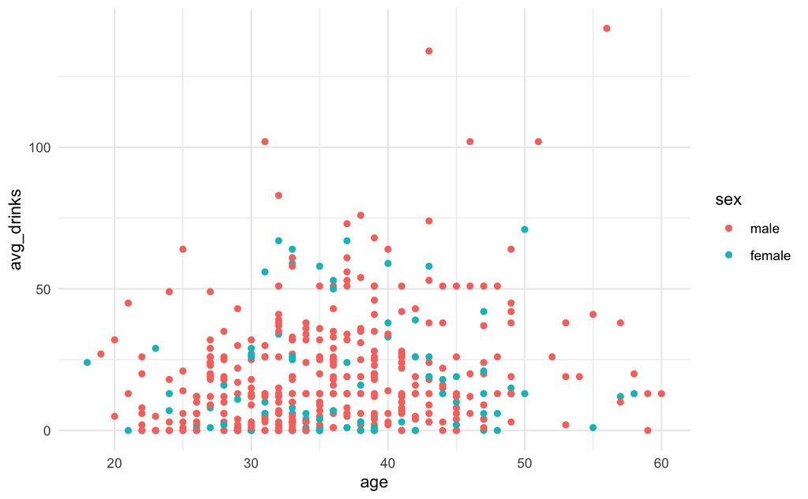

```r
# Your Code here.
ggplot(HELPmiss) +
  aes(x = age, y = avg_drinks, colour = sex) +
  geom_point(shape = "circle", size = 1.5) +
  scale_color_hue(direction = 1) +
  theme_minimal()
```